# NYC Airbnb

Marcel Socorro

September 9, 2020

```r
library(dplyr)
library(ggmap)
```

```r
library(maptools)
library(tidyverse)
library(RColorBrewer)
library(rpart)
library(e1071)
library(rpart.plot)
library(nnet)
library(AICcmodavg)
data<-read_csv("AB_NYC_2019.csv")
data1<-subset(data,data$availability_365>0)
```

```r
# store bounding box coordinates
nyc_bb <- c(left = -74.250000,
            bottom = 40.490000,
            right = -73.710000,
            top = 40.9140000)

nyc_stamen <- get_stamenmap(bbox = nyc_bb,
                                zoom = 9)
# store bounding box coordinates
nyc_bb1 <- c(left = -74.150000,
            bottom = 40.630000,
            right = -73.850000,
            top = 40.8700000)

nyc_stamen1 <- get_stamenmap(bbox = nyc_bb1,
                                zoom = 11)
```

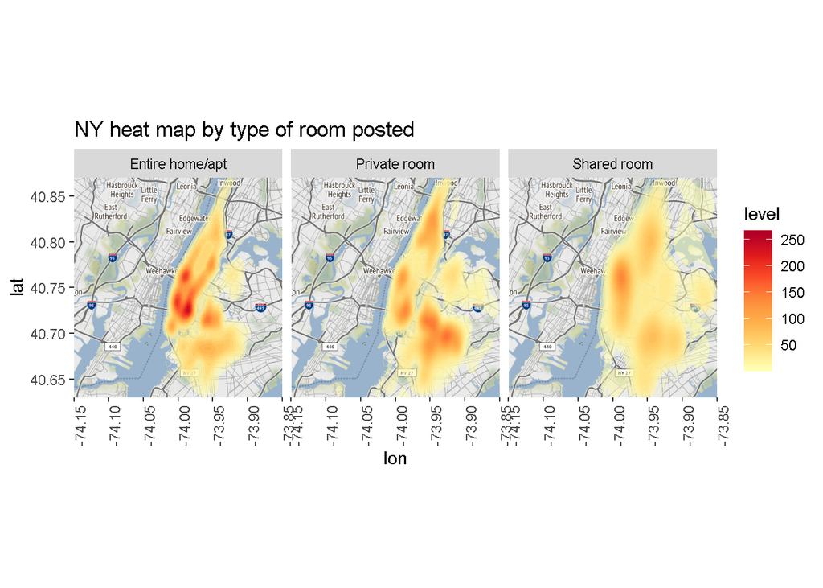

```r
ggmap(nyc_stamen1) +
  stat_density_2d(data = data,
                  aes(x = longitude,
                      y = latitude,
                      fill = stat(level)),
                  alpha = .5,
                  bins = 25,
                  geom = "polygon") +
  scale_fill_gradientn(colors = brewer.pal(7, "YlOrRd"))+facet_wrap(~ `room_type`)+theme(axis.text.x = element_text(angle = 90))+labs(title= "NY heat map by type of room posted")
```

[figure not shown]

```r
ggmap(nyc_stamen1) +
  stat_density_2d(data = data,
                  aes(x = longitude,
                      y = latitude,
                      fill = stat(level)),
                  alpha = .8,
                  bins = 25,
                  geom = "polygon") +
  scale_fill_gradientn(colors = brewer.pal(7, "YlOrRd"))+labs(title= "NY heat map posting location")
```

[figure not shown]

```r
ggmap(nyc_stamen1) +
  geom_point(data = data,
             aes(x = longitude,
                 y = latitude),
             size = .25,
             alpha = .1)+facet_wrap(~ `neighbourhood_group`)+labs(title= "NY heat map posting location by neighborhood")
```

```r
byNeighbourhood<-group_by(data1,neighbourhood_group)
summary<-summarize(byNeighbourhood,mean(price))
```

[figure not shown]

```r
summary$`mean(price)`<-round(summary$`mean(price)`, 2)
ggplot(summary,aes(x=neighbourhood_group,y=summary$`mean(price)`, fill=neighbourhood_group))+geom_bar(stat='identity', color="black")+labs(title="Average price per night Airbnb by NYC Neighbourhood",x="NYC Neighbourhood",y="Avg price per night ($)")+ geom_text(aes(label=summary$`mean(price)`), vjust=-.25)
```

```r
byNeighbourhood1<-group_by(data1,neighbourhood_group,room_type)
summary1<-summarize(byNeighbourhood1,mean(price))
```

[figure not shown]

```r
summary1$`mean(price)`<-round(summary1$`mean(price)`, 2)
ggplot(summary1,aes(x=neighbourhood_group,y=summary1$`mean(price)`,fill=neighbourhood_group))+geom_bar(stat='identity', color="black")+labs(title="Average price per night Airbnb by NYC Neighbourhood and Room Type",x="NYC Neighbourhood",y="Avg price per night ($)")+ geom_text(size=2.5,aes(label=summary1$`mean(price)`), vjust=-.25)+facet_wrap(~room_type)+ theme(axis.text.x = element_text(angle = 45,size=7))
```

```r
summary(data$price)
```

```
##    Min. 1st Qu.  Median    Mean 3rd Qu.    Max.
##     0.0    69.0   106.0   152.7   175.0 10000.0
```

Based on the previous summary(1Q, Median and 3Q), 4 different classes will be generated. 0-69 $/night—-economic 69-106 $/night–standard 106-175 $/night-comfort 175-Max $/night-luxury

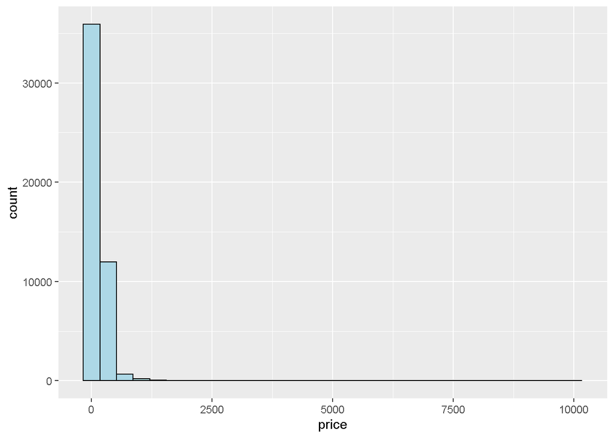

```r
#Histogram variable price. The wide range in the variable prices does not allow get a proper information from the historgram
ggplot(data,aes(price))+geom_histogram(fill="light blue", color="black")
```

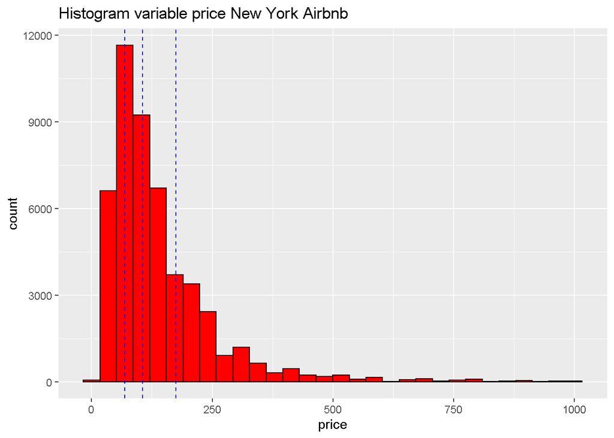

```r
#If subset is applied for prices higher than 1000 usd/night we could get a better understanding for price distribution
pricesbelow1000<-subset(data,price<1000)
ggplot(pricesbelow1000,aes(price))+geom_histogram(fill="red", color="black")+labs(title = "Histogram variable price New York Airbnb")+geom_vline(xintercept=69, linetype="dashed", color = "blue")+geom_vline(xintercept=106, linetype="dashed", color = "blue")+geom_vline(xintercept=175, linetype="dashed", color = "blue")
```

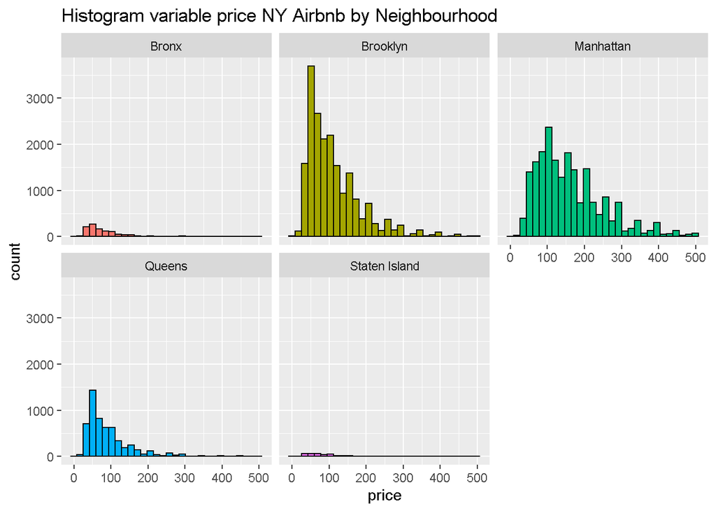

```r
pricesbelow500<-subset(data,price<500)
ggplot(pricesbelow500,aes(price,fill=neighbourhood_group))+geom_histogram(color="black", show.legend = FALSE)+facet_wrap(~neighbourhood_group)+labs(title = "Histogram variable price NY Airbnb by Neighbourhood")
```

```r
#Creating the class based on the price
data$class<-ifelse(data$price>0&data$price<69,"economic",ifelse(data$price>=69&data$price<106,"standard",ifelse(data$price>=106&data$price<175,"comfort","luxury")))
data$class<-as.factor(data$class)
```

```r
#Function accuracy values per different samples
accuracyNBLag<-function(trials){
  acc <- data.frame(i = integer(),Accuracy= integer())
  for(i in 420:trials) {
  # random sample
  smp_size <- floor(0.75 * nrow(data))
## set the seed to make the partition reproducible
set.seed(i)
train_ind <- sample(seq_len(nrow(data)), size = smp_size)
trainC <- data[train_ind, ]
testC <- data[-train_ind, ]
NBmodelC<-naiveBayes(class~neighbourhood_group+room_type+minimum_nights+number_of_reviews,data=trainC,laplace = 1)
NB_prediction1C<-predict(NBmodelC,testC, type = "class")
confumatNB<-data.frame(Actual=testC$class,Prediction=NB_prediction1C)
accuracy<-nrow(subset(confumatNB,Actual==Prediction))/nrow(confumatNB)
accuracy
trial=i
attempt <- data.frame(Trial = trial, Accuracy = accuracy)
acc <- rbind(acc,attempt)
  }
  return(acc)
}
```

```r
accuracyNB30Lag<-accuracyNBLag(450)
```

[output not shown]

[output cut: 130 more lines]

[output not shown]

```r
avgNB<-data.frame("AvgAccuracy"=mean(accuracyNB30Lag$Accuracy),"model"="NB")
cat("The average accuracy for Naïve Bayes model with 30 different sampling split of training and testing set is:",avgNB$AvgAccuracy)
```

```
## The average accuracy for Naïve Bayes model with 30 different sampling split of training and testing set is: 0.5032828
```

```r
#Function accuracy values per different samples
accuracyRFLag<-function(trials){
  acc <- data.frame(i = integer(),Accuracy= integer())
  for(i in 420:trials) {
  # random sample
  smp_size <- floor(0.75 * nrow(data))
## set the seed to make the partition reproducible
set.seed(i)
train_ind <- sample(seq_len(nrow(data)), size = smp_size)
trainC <- data[train_ind, ]
testC <- data[-train_ind, ]
RFmodelC<-rpart(class~neighbourhood_group+room_type+minimum_nights+number_of_reviews+availability_365, data=trainC, method="class")
RF_prediction1C<-predict(RFmodelC,testC, type = "class")
confumatRF<-data.frame(Actual=testC$class,Prediction=RF_prediction1C)
accuracy<-nrow(subset(confumatRF,Actual==Prediction))/nrow(confumatRF)
accuracy
trial=i
attempt <- data.frame(Trial = trial, Accuracy = accuracy)
acc <- rbind(acc,attempt)
  }
  return(acc)
}
```

```r
accuracyRF30Lag<-accuracyRFLag(450)
```

```r
avgRF<-data.frame("AvgAccuracy"=mean(accuracyRF30Lag$Accuracy),"model"="CART")
cat("The average accuracy for CART model with 30 different sampling split of training and testing set is:",avgRF$AvgAccuracy)
```

```
## The average accuracy for CART model with 30 different sampling split of training and testing set is: 0.516604
```

```r
#Function accuracy values per different samples
accuracyANNLag<-function(trials){
  acc <- data.frame(i = integer(),Accuracy= integer())
  for(i in 420:trials) {
  # random sample
  smp_size <- floor(0.75 * nrow(data))
## set the seed to make the partition reproducible
set.seed(i)
train_ind <- sample(seq_len(nrow(data)), size = smp_size)
trainC <- data[train_ind, ]
testC <- data[-train_ind, ]
modelANNC<-nnet(class~neighbourhood_group+room_type+minimum_nights+number_of_reviews+availability_365,data=trainC,size = 3,decay = 0.0001,maxit = 500)
pred_nnet<-predict(modelANNC,testC,type="class")
confumatANN<-data.frame(Actual=testC$class,Prediction=pred_nnet)
accuracy<-nrow(subset(confumatANN,Actual==Prediction))/nrow(confumatANN)
accuracy
trial=i
attempt <- data.frame(Trial = trial, Accuracy = accuracy)
acc <- rbind(acc,attempt)
  }
  return(acc)
}
```

```r
accuracyANN30Lag<-accuracyANNLag(450)
avgANN<-data.frame("AvgAccuracy"=mean(accuracyANN30Lag$Accuracy),"model"="ANN")
cat("The average accuracy for ANN model with 30 different sampling split of training and testing set is:",avgANN$AvgAccuracy)
```

```
## The average accuracy for ANN model with 30 different sampling split of training and testing set is: 0.5277825
```

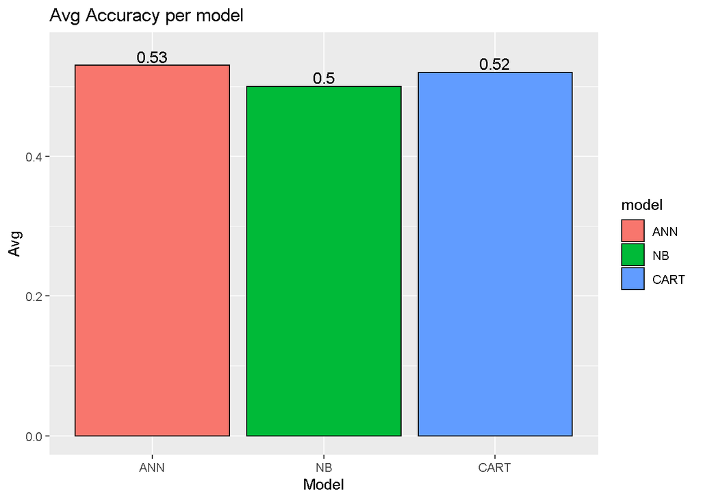

```r
avgAccuracyModels<-rbind(avgANN,avgNB,avgRF)
avgAccuracyModels$AvgAccuracy<-round(avgAccuracyModels$AvgAccuracy,2)
ggplot(avgAccuracyModels,aes(model,AvgAccuracy,fill=model))+geom_bar(position = "dodge",stat = "identity",color="black")+ylim(0,0.55)+ geom_text(size=4,aes(label=AvgAccuracy), vjust=-.25)+labs(title="Avg Accuracy per model", x="Model", y="Avg")
```

```r
accuracyANN30Lag$model<-"ANN"
accuracyRF30Lag$model<-"CART"
accuracyNB30Lag$model<-"NB"
accuracyModels<-rbind(accuracyANN30Lag,accuracyRF30Lag,accuracyNB30Lag)
Anova<-aov(Accuracy~model,data = accuracyModels)
summary(Anova)
```

```
##             Df   Sum Sq  Mean Sq F value Pr(>F)
## model        2 0.009327 0.004664   151.9 <2e-16 ***
## Residuals   90 0.002764 0.000031
## ---
## Signif. codes:  0 '***' 0.001 '**' 0.01 '*' 0.05 '.' 0.1 ' ' 1
```

According to Anova results with a pvalue less than alpha (0.05) there is a significant difference among the models for the set of accuracy results obtained. Which is the model significantly different?

```r
TukeyHSD(Anova)
```

```
##   Tukey multiple comparisons of means
##     95% family-wise confidence level
##
## Fit: aov(formula = Accuracy ~ model, data = accuracyModels)
##
## $model
##                 diff         lwr          upr p adj
## CART-ANN -0.01117843 -0.01453290 -0.007823967     0
## NB-ANN   -0.02449966 -0.02785413 -0.021145197     0
## NB-CART  -0.01332123 -0.01667569 -0.009966764     0
```

According to Tukey test, the 3 pairs are significantly different between them. ANN has the highest avg accuracy so it will be chosen as the best model to predict the variable class determined by 4 pricing ranges.

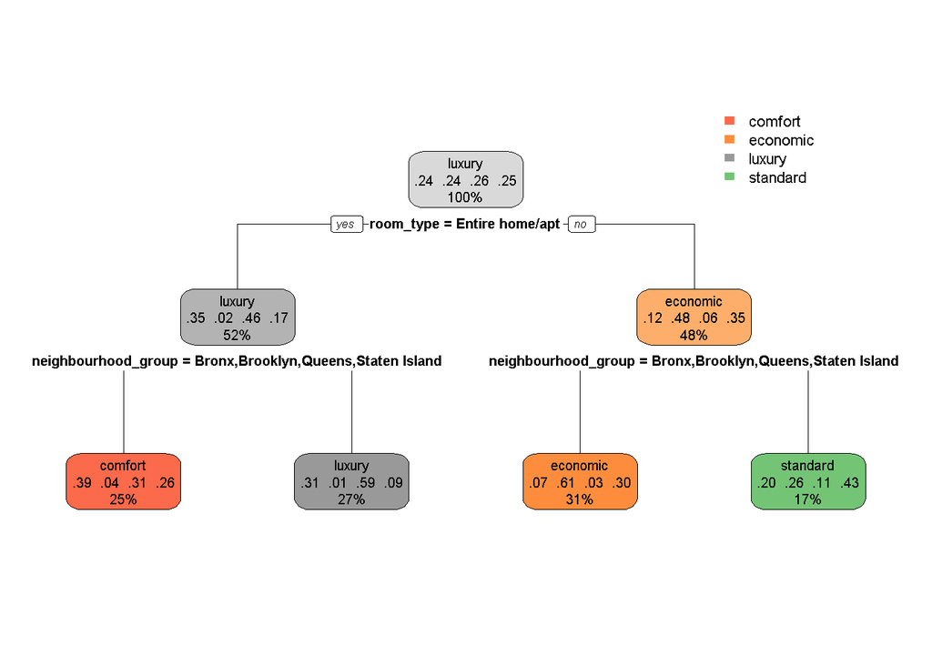

```r
#If a graph of a Regression and Classification tree is plotted, it could be seen that the variables impacting in the class are "neighborhood_group" and room_type
smp_size <- floor(0.75 * nrow(data))
set.seed(123)
train_ind <- sample(seq_len(nrow(data)), size = smp_size)
trainC <- data[train_ind, ]
testC <- data[-train_ind, ]
RFmodelC<-rpart(class~neighbourhood_group+room_type+minimum_nights+number_of_reviews+availability_365, data=trainC, method="class")

rpart.plot(RFmodelC)
```

let’s run a Two-way Anova to determine which are the combinations from variables room_type and neighbourhood_group significantly different.

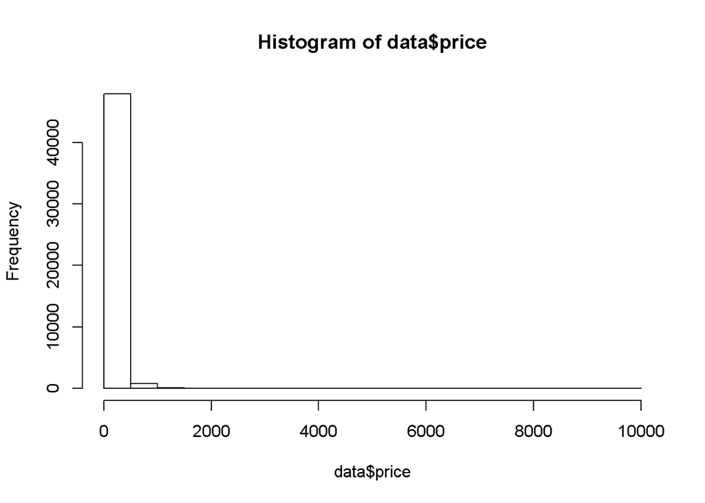

```r
## The populations from which the samples were obtained must be normally or approximately normally distributed.
hist(data$price)
```

Prices around 10000 $/night will be considered as outliers, this kind of prices are too exclusive and distant from the rest of the population, so let’s subset and consider the data for the population below than 500 usd/night.

```r
sampleNormal<-data.frame("price"=sample(pricesbelow500$price,5000))
shapiro.test(sampleNormal$price)
```

```
##
##  Shapiro-Wilk normality test
##
## data:  sampleNormal$price
## W = 0.87083, p-value < 2.2e-16
```

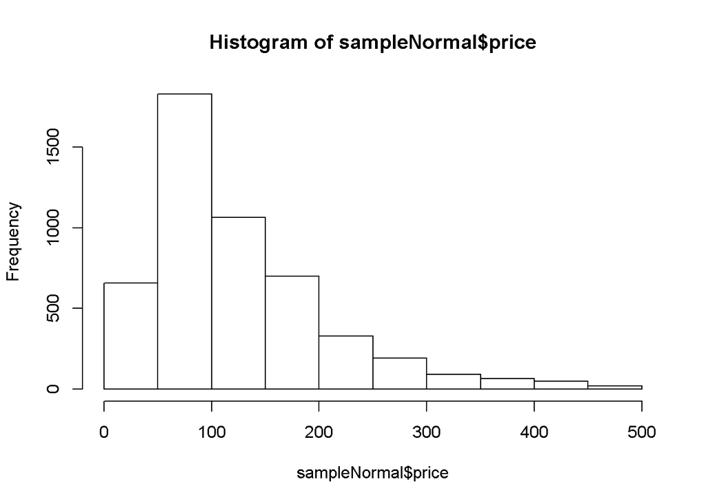

```r
hist(sampleNormal$price)
```

According to shapiro test p value is less than alpha so the data can’t be considered as normal, so let’s try to transformate the data. Since division by zero is a problem, log+1 transformation would be better.

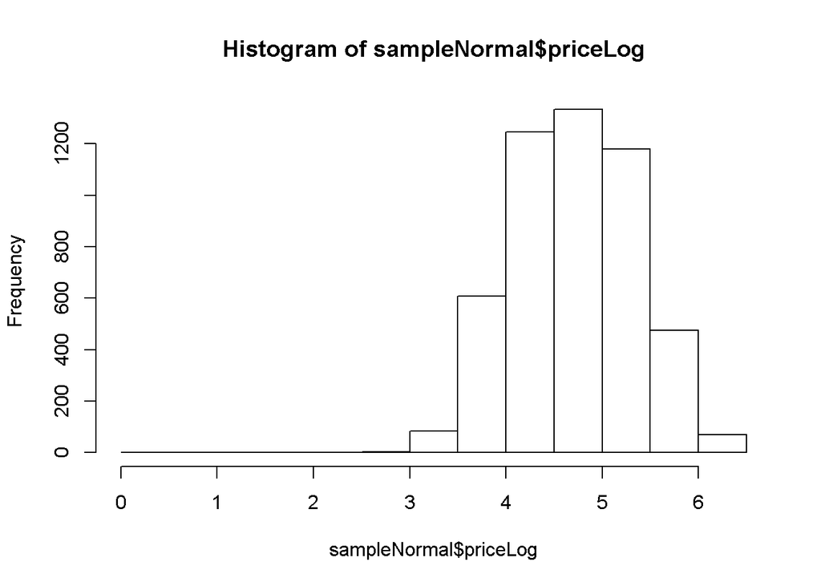

```r
sampleNormal$priceLog<- log(sampleNormal$price+1)
hist(sampleNormal$priceLog)
```

```r
shapiro.test(sampleNormal$priceLog)
```

```
##
##  Shapiro-Wilk normality test
##
## data:  sampleNormal$priceLog
## W = 0.99167, p-value < 2.2e-16
```

Applying the same test upon the data transformed, we got pvalue less than alpha, so the null hypothesis the data is normal is rejected. For this particular case since the dataset has 47k rows let’s apply the Central Limit Theorem, for which if the population is not normally distributed, but the sample size is sufficiently large, then the sample means will have an approximately normal distribution. So, let’s proceed with the next assumption. Some books define sufficiently large as at least 30 and others as at least 31.

```r
## The variances of the populations must be equal.
groupByRoomNeigh<-group_by(pricesbelow500,room_type,neighbourhood_group)
byRoomNeigh<-summarise(groupByRoomNeigh,
                       "stdPrice"=sd(price),
                       "qtyObservations"=n())
byRoomNeigh
```

```
## # A tibble: 15 x 4
## # Groups:   room_type [3]
##    room_type       neighbourhood_group stdPrice qtyObservations
##    <chr>           <chr>                  <dbl>           <int>
##  1 Entire home/apt Bronx                   72.8             375
##  2 Entire home/apt Brooklyn                75.7            9325
##  3 Entire home/apt Manhattan               87.0           12416
##  4 Entire home/apt Queens                  71.0            2073
##  5 Entire home/apt Staten Island           70.3             170
##  6 Private room    Bronx                   32.0             648
##  7 Private room    Brooklyn                36.7           10088
##  8 Private room    Manhattan               59.7            7865
##  9 Private room    Queens                  36.3            3363
## 10 Private room    Staten Island           36.1             188
## 11 Shared room     Bronx                   30.6              59
## 12 Shared room     Brooklyn                41.9             412
## 13 Shared room     Manhattan               63.2             475
## 14 Shared room     Queens                  34.0             194
## 15 Shared room     Staten Island           45.1               9
```

There is a relative difference between variance of all populations, but let’s assume that this difference it is not representative. Going back to Central Limit Theorem, the size of the samples to be considered as sufficiently large should be greater than 31 observations. The combination Shared room—Staten Island doesn’t meet the large of the size (9). For this combination it will be used replacement of the values option (using the Parameter TRUE in the function sample) duplicating the same values until we get the size of the sample required, in this case it will be set on 40 observations.

```r
## The groups must have the same sample size.
set.seed(123)
sampleAnova <- pricesbelow500 %>% group_by(neighbourhood_group,room_type) %>% sample_n(40, TRUE)
```

```r
#Because we have a few different possible relationships between our variables, we will compare two models:

#1-A two-way ANOVA without any interaction or blocking variable (a.k.a an additive two-way ANOVA).assumes there is no interaction between the two independent variables
#2-A two-way ANOVA with interaction but with no blocking variable.assumes that there is an interaction between the two independent variables

#1-Two way ANOVA
two.way <- aov(price ~ neighbourhood_group + room_type, data = sampleAnova)

#2-Two-way ANOVA with interaction
interaction <- aov(price ~ neighbourhood_group * room_type, data = sampleAnova)
```

```r
model.set <- list(two.way, interaction)
model.names <- c("two.way", "interaction")

aictab(model.set, modnames = model.names)
```

```
##
## Model selection based on AICc:
##
##              K    AICc Delta_AICc AICcWt Cum.Wt       LL
## two.way      8 6600.60       0.00   0.54   0.54 -3292.18
## interaction 16 6600.93       0.33   0.46   1.00 -3284.00
```

The AIC model with the best fit will be listed first, with the second-best listed next, and so on. This comparison reveals that two way ANOVA without interaction is the best fit for the data.

```r
summary(two.way)
```

```
##                      Df  Sum Sq Mean Sq F value   Pr(>F)
## neighbourhood_group   4  244430   61108   17.68 1.01e-13 ***
## room_type             2  899013  449506  130.07  < 2e-16 ***
## Residuals           593 2049251    3456
## ---
## Signif. codes:  0 '***' 0.001 '**' 0.01 '*' 0.05 '.' 0.1 ' ' 1
```

For the row factor room_type P-value < 2e-16 < α Reject H0 so there is an effect from the row factor (room_type) and at least one row mean is different from the other.

```r
TukeyHSD(two.way)
```

```
##   Tukey multiple comparisons of means
##     95% family-wise confidence level
##
## Fit: aov(formula = price ~ neighbourhood_group + room_type, data = sampleAnova)
##
## $neighbourhood_group
##                              diff        lwr        upr     p adj
## Brooklyn-Bronx           18.83333  -1.932088  39.598754 0.0961767
## Manhattan-Bronx          54.12500  33.359579  74.890421 0.0000000
## Queens-Bronx              0.80000 -19.965421  21.565421 0.9999721
## Staten Island-Bronx       6.60000 -14.165421  27.365421 0.9079266
## Manhattan-Brooklyn       35.29167  14.526246  56.057088 0.0000401
## Queens-Brooklyn         -18.03333 -38.798754   2.732088 0.1232760
## Staten Island-Brooklyn  -12.23333 -32.998754   8.532088 0.4902690
## Queens-Manhattan        -53.32500 -74.090421 -32.559579 0.0000000
## Staten Island-Manhattan -47.52500 -68.290421 -26.759579 0.0000000
## Staten Island-Queens      5.80000 -14.965421  26.565421 0.9407024
##
## $room_type
##                                 diff       lwr      upr     p adj
## Private room-Entire home/apt -70.985  -84.7973 -57.1727 0.0000000
## Shared room-Entire home/apt  -89.930 -103.7423 -76.1177 0.0000000
## Shared room-Private room     -18.945  -32.7573  -5.1327 0.0038252
```

```r
tukey<-TukeyHSD(two.way)
NeighbourhoodCombinations<-data.frame(tukey[1])
colnames(NeighbourhoodCombinations)<-c("diff","lwr","upr","p.adj")
RoomsCombinations<-data.frame(tukey[2])
colnames(RoomsCombinations)<-c("diff","lwr","upr","p.adj")
twoWayTable<-rbind(NeighbourhoodCombinations,RoomsCombinations)
twoWayData <- cbind(Combination = rownames(twoWayTable), twoWayTable)
rownames(twoWayTable) <- 1:nrow(twoWayTable)
rownames(twoWayData) <- NULL
CombSignDiff<-subset(twoWayData,p.adj<0.05)
CombNotSignDiff<-subset(twoWayData,p.adj>=0.05)
CombSignDiff<-CombSignDiff[,c(1,5)]
CombSignDiff
```

```
##                     Combination        p.adj
## 2               Manhattan-Bronx 5.118007e-10
## 5            Manhattan-Brooklyn 4.014856e-05
## 8              Queens-Manhattan 5.412145e-10
## 9       Staten Island-Manhattan 7.765517e-09
## 11 Private room-Entire home/apt 4.828220e-10
## 12  Shared room-Entire home/apt 4.828218e-10
## 13     Shared room-Private room 3.825168e-03
```

```r
CombNotSignDiff<-CombNotSignDiff[,c(1,5)]
CombNotSignDiff
```

```
##               Combination     p.adj
## 1          Brooklyn-Bronx 0.0961767
## 3            Queens-Bronx 0.9999721
## 4     Staten Island-Bronx 0.9079266
## 6         Queens-Brooklyn 0.1232760
## 7  Staten Island-Brooklyn 0.4902690
## 10   Staten Island-Queens 0.9407024
```